# 03_octave_phase

## 03_octave_phase

#### Question

1. In [additive synthesis](https://en.wikipedia.org/wiki/Additive_synthesis), a musician combines [pure tones](https://en.wikipedia.org/wiki/Pure_tone) by adding together sine waves to produce a large variety of tones.

   In harmonic additive synthesis, a sine wave with a [fundamental frequency](https://en.wikipedia.org/wiki/Fundamental_frequencybvcvc) is added to sine waves with positive-integer multiples of the fundamental frequency. Each harmonic has its own amplitude and phase shift. The exact set of frequencies, their amplitudes, and their phases dictates the [timbre](https://en.wikipedia.org/wiki/Timbre) of the [musical tone](https://en.wikipedia.org/wiki/Musical_tone).

   For example, the musician might combine a sine wave with amplitude of 1 and frequency of 100 Hz with another sine wave with amplitude 1 and frequency of 200 Hz. In [Desmos](https://www.desmos.com/calculator), you can generate this tone with `tone([100,200],[1,1])`.

   Interestingly, Desmos does not allow us to control the phase of the component waves when using the `tone` function. In most cases, the [psychoacoustic](https://en.wikipedia.org/wiki/Psychoacoustics) perception (of human hearing) won’t distinguish between various phase shifts. However, we can see some striking visual changes to the [waveform](https://en.wikipedia.org/wiki/Waveform) when we change the initial phase of a component.

   For example, in Desmos, type the following equation, using a slider for $c$.

   $$y~~=~~\sin(2\pi100 t)~+~\sin(2\pi 200 t+c)$$

   The slider $c$ represents a horizontal shift in the 200-Hz wave. **Find the (approximate) value of $c$, such that $0\le c < 2\pi$ to achieve the waveform shown below:**

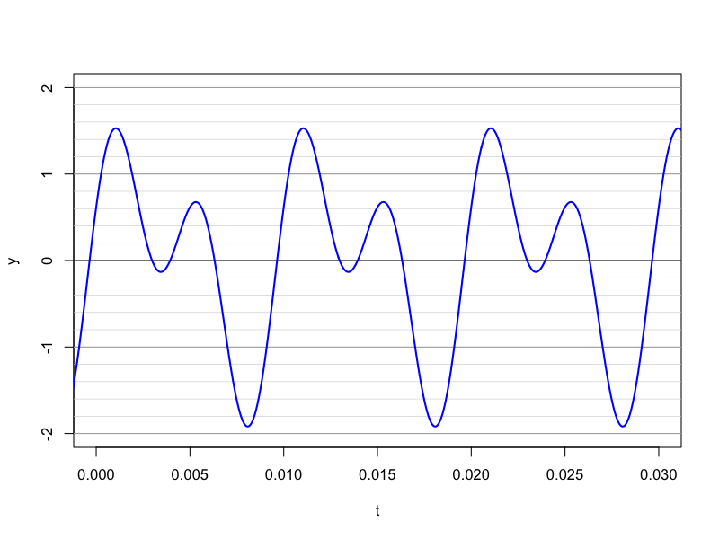

   Notice, you’ll need to selectively zoom in on the horizontal axis.

#### Question

2. In [additive synthesis](https://en.wikipedia.org/wiki/Additive_synthesis), a musician combines [pure tones](https://en.wikipedia.org/wiki/Pure_tone) by adding together sine waves to produce a large variety of tones.

   In harmonic additive synthesis, a sine wave with a [fundamental frequency](https://en.wikipedia.org/wiki/Fundamental_frequencybvcvc) is added to sine waves with positive-integer multiples of the fundamental frequency. Each harmonic has its own amplitude and phase shift. The exact set of frequencies, their amplitudes, and their phases dictates the [timbre](https://en.wikipedia.org/wiki/Timbre) of the [musical tone](https://en.wikipedia.org/wiki/Musical_tone).

   For example, the musician might combine a sine wave with amplitude of 1 and frequency of 100 Hz with another sine wave with amplitude 1 and frequency of 200 Hz. In [Desmos](https://www.desmos.com/calculator), you can generate this tone with `tone([100,200],[1,1])`.

   Interestingly, Desmos does not allow us to control the phase of the component waves when using the `tone` function. In most cases, the [psychoacoustic](https://en.wikipedia.org/wiki/Psychoacoustics) perception (of human hearing) won’t distinguish between various phase shifts. However, we can see some striking visual changes to the [waveform](https://en.wikipedia.org/wiki/Waveform) when we change the initial phase of a component.

   For example, in Desmos, type the following equation, using a slider for $c$.

   $$y~~=~~\sin(2\pi100 t)~+~\sin(2\pi 200 t+c)$$

   The slider $c$ represents a horizontal shift in the 200-Hz wave. **Find the (approximate) value of $c$, such that $0\le c < 2\pi$ to achieve the waveform shown below:**

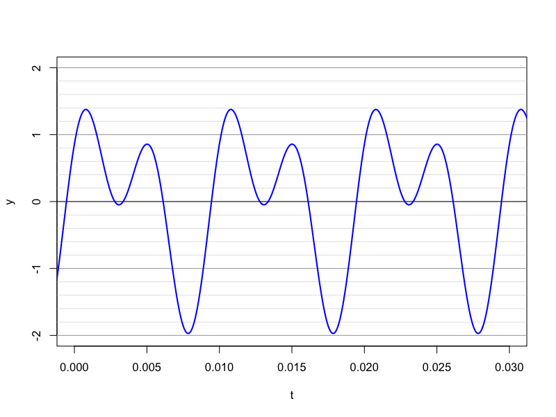

   Notice, you’ll need to selectively zoom in on the horizontal axis.

#### Question

3. In [additive synthesis](https://en.wikipedia.org/wiki/Additive_synthesis), a musician combines [pure tones](https://en.wikipedia.org/wiki/Pure_tone) by adding together sine waves to produce a large variety of tones.

   In harmonic additive synthesis, a sine wave with a [fundamental frequency](https://en.wikipedia.org/wiki/Fundamental_frequencybvcvc) is added to sine waves with positive-integer multiples of the fundamental frequency. Each harmonic has its own amplitude and phase shift. The exact set of frequencies, their amplitudes, and their phases dictates the [timbre](https://en.wikipedia.org/wiki/Timbre) of the [musical tone](https://en.wikipedia.org/wiki/Musical_tone).

   For example, the musician might combine a sine wave with amplitude of 1 and frequency of 100 Hz with another sine wave with amplitude 1 and frequency of 200 Hz. In [Desmos](https://www.desmos.com/calculator), you can generate this tone with `tone([100,200],[1,1])`.

   Interestingly, Desmos does not allow us to control the phase of the component waves when using the `tone` function. In most cases, the [psychoacoustic](https://en.wikipedia.org/wiki/Psychoacoustics) perception (of human hearing) won’t distinguish between various phase shifts. However, we can see some striking visual changes to the [waveform](https://en.wikipedia.org/wiki/Waveform) when we change the initial phase of a component.

   For example, in Desmos, type the following equation, using a slider for $c$.

   $$y~~=~~\sin(2\pi100 t)~+~\sin(2\pi 200 t+c)$$

   The slider $c$ represents a horizontal shift in the 200-Hz wave. **Find the (approximate) value of $c$, such that $0\le c < 2\pi$ to achieve the waveform shown below:**

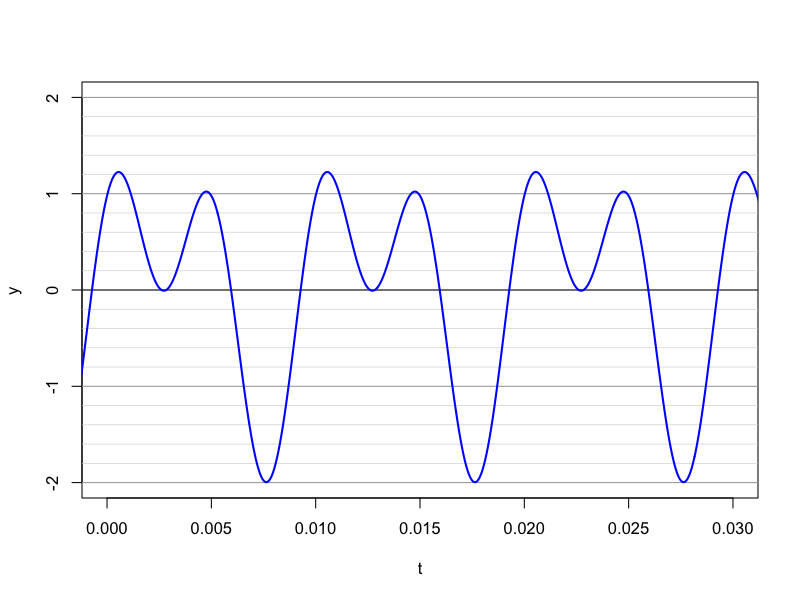

   Notice, you’ll need to selectively zoom in on the horizontal axis.

#### Question

4. In [additive synthesis](https://en.wikipedia.org/wiki/Additive_synthesis), a musician combines [pure tones](https://en.wikipedia.org/wiki/Pure_tone) by adding together sine waves to produce a large variety of tones.

   In harmonic additive synthesis, a sine wave with a [fundamental frequency](https://en.wikipedia.org/wiki/Fundamental_frequencybvcvc) is added to sine waves with positive-integer multiples of the fundamental frequency. Each harmonic has its own amplitude and phase shift. The exact set of frequencies, their amplitudes, and their phases dictates the [timbre](https://en.wikipedia.org/wiki/Timbre) of the [musical tone](https://en.wikipedia.org/wiki/Musical_tone).

   For example, the musician might combine a sine wave with amplitude of 1 and frequency of 100 Hz with another sine wave with amplitude 1 and frequency of 200 Hz. In [Desmos](https://www.desmos.com/calculator), you can generate this tone with `tone([100,200],[1,1])`.

   Interestingly, Desmos does not allow us to control the phase of the component waves when using the `tone` function. In most cases, the [psychoacoustic](https://en.wikipedia.org/wiki/Psychoacoustics) perception (of human hearing) won’t distinguish between various phase shifts. However, we can see some striking visual changes to the [waveform](https://en.wikipedia.org/wiki/Waveform) when we change the initial phase of a component.

   For example, in Desmos, type the following equation, using a slider for $c$.

   $$y~~=~~\sin(2\pi100 t)~+~\sin(2\pi 200 t+c)$$

   The slider $c$ represents a horizontal shift in the 200-Hz wave. **Find the (approximate) value of $c$, such that $0\le c < 2\pi$ to achieve the waveform shown below:**

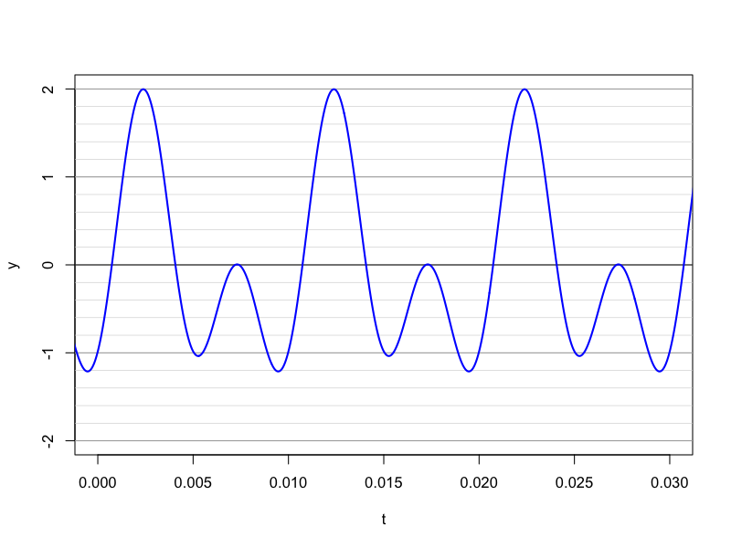

   Notice, you’ll need to selectively zoom in on the horizontal axis.

#### Question

5. In [additive synthesis](https://en.wikipedia.org/wiki/Additive_synthesis), a musician combines [pure tones](https://en.wikipedia.org/wiki/Pure_tone) by adding together sine waves to produce a large variety of tones.

   In harmonic additive synthesis, a sine wave with a [fundamental frequency](https://en.wikipedia.org/wiki/Fundamental_frequencybvcvc) is added to sine waves with positive-integer multiples of the fundamental frequency. Each harmonic has its own amplitude and phase shift. The exact set of frequencies, their amplitudes, and their phases dictates the [timbre](https://en.wikipedia.org/wiki/Timbre) of the [musical tone](https://en.wikipedia.org/wiki/Musical_tone).

   For example, the musician might combine a sine wave with amplitude of 1 and frequency of 100 Hz with another sine wave with amplitude 1 and frequency of 200 Hz. In [Desmos](https://www.desmos.com/calculator), you can generate this tone with `tone([100,200],[1,1])`.

   Interestingly, Desmos does not allow us to control the phase of the component waves when using the `tone` function. In most cases, the [psychoacoustic](https://en.wikipedia.org/wiki/Psychoacoustics) perception (of human hearing) won’t distinguish between various phase shifts. However, we can see some striking visual changes to the [waveform](https://en.wikipedia.org/wiki/Waveform) when we change the initial phase of a component.

   For example, in Desmos, type the following equation, using a slider for $c$.

   $$y~~=~~\sin(2\pi100 t)~+~\sin(2\pi 200 t+c)$$

   The slider $c$ represents a horizontal shift in the 200-Hz wave. **Find the (approximate) value of $c$, such that $0\le c < 2\pi$ to achieve the waveform shown below:**

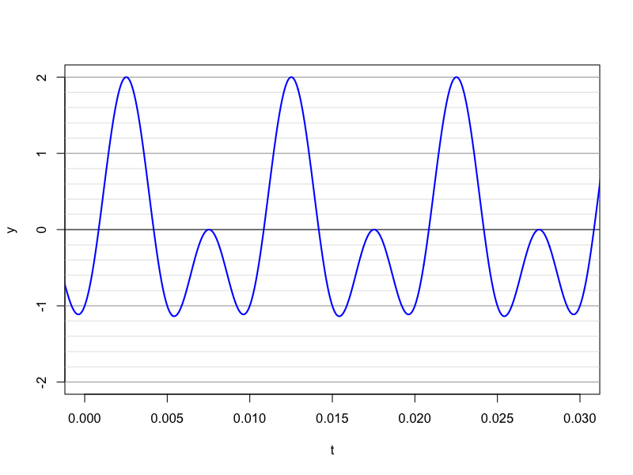

   Notice, you’ll need to selectively zoom in on the horizontal axis.

#### Question

6. In [additive synthesis](https://en.wikipedia.org/wiki/Additive_synthesis), a musician combines [pure tones](https://en.wikipedia.org/wiki/Pure_tone) by adding together sine waves to produce a large variety of tones.

   In harmonic additive synthesis, a sine wave with a [fundamental frequency](https://en.wikipedia.org/wiki/Fundamental_frequencybvcvc) is added to sine waves with positive-integer multiples of the fundamental frequency. Each harmonic has its own amplitude and phase shift. The exact set of frequencies, their amplitudes, and their phases dictates the [timbre](https://en.wikipedia.org/wiki/Timbre) of the [musical tone](https://en.wikipedia.org/wiki/Musical_tone).

   For example, the musician might combine a sine wave with amplitude of 1 and frequency of 100 Hz with another sine wave with amplitude 1 and frequency of 200 Hz. In [Desmos](https://www.desmos.com/calculator), you can generate this tone with `tone([100,200],[1,1])`.

   Interestingly, Desmos does not allow us to control the phase of the component waves when using the `tone` function. In most cases, the [psychoacoustic](https://en.wikipedia.org/wiki/Psychoacoustics) perception (of human hearing) won’t distinguish between various phase shifts. However, we can see some striking visual changes to the [waveform](https://en.wikipedia.org/wiki/Waveform) when we change the initial phase of a component.

   For example, in Desmos, type the following equation, using a slider for $c$.

   $$y~~=~~\sin(2\pi100 t)~+~\sin(2\pi 200 t+c)$$

   The slider $c$ represents a horizontal shift in the 200-Hz wave. **Find the (approximate) value of $c$, such that $0\le c < 2\pi$ to achieve the waveform shown below:**

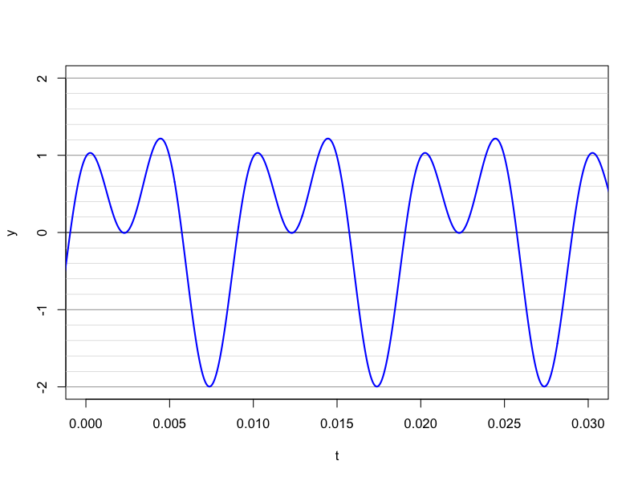

   Notice, you’ll need to selectively zoom in on the horizontal axis.

#### Question

7. In [additive synthesis](https://en.wikipedia.org/wiki/Additive_synthesis), a musician combines [pure tones](https://en.wikipedia.org/wiki/Pure_tone) by adding together sine waves to produce a large variety of tones.

   In harmonic additive synthesis, a sine wave with a [fundamental frequency](https://en.wikipedia.org/wiki/Fundamental_frequencybvcvc) is added to sine waves with positive-integer multiples of the fundamental frequency. Each harmonic has its own amplitude and phase shift. The exact set of frequencies, their amplitudes, and their phases dictates the [timbre](https://en.wikipedia.org/wiki/Timbre) of the [musical tone](https://en.wikipedia.org/wiki/Musical_tone).

   For example, the musician might combine a sine wave with amplitude of 1 and frequency of 100 Hz with another sine wave with amplitude 1 and frequency of 200 Hz. In [Desmos](https://www.desmos.com/calculator), you can generate this tone with `tone([100,200],[1,1])`.

   Interestingly, Desmos does not allow us to control the phase of the component waves when using the `tone` function. In most cases, the [psychoacoustic](https://en.wikipedia.org/wiki/Psychoacoustics) perception (of human hearing) won’t distinguish between various phase shifts. However, we can see some striking visual changes to the [waveform](https://en.wikipedia.org/wiki/Waveform) when we change the initial phase of a component.

   For example, in Desmos, type the following equation, using a slider for $c$.

   $$y~~=~~\sin(2\pi100 t)~+~\sin(2\pi 200 t+c)$$

   The slider $c$ represents a horizontal shift in the 200-Hz wave. **Find the (approximate) value of $c$, such that $0\le c < 2\pi$ to achieve the waveform shown below:**

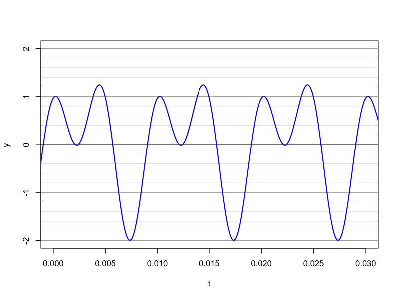

   Notice, you’ll need to selectively zoom in on the horizontal axis.

#### Question

8. In [additive synthesis](https://en.wikipedia.org/wiki/Additive_synthesis), a musician combines [pure tones](https://en.wikipedia.org/wiki/Pure_tone) by adding together sine waves to produce a large variety of tones.

   In harmonic additive synthesis, a sine wave with a [fundamental frequency](https://en.wikipedia.org/wiki/Fundamental_frequencybvcvc) is added to sine waves with positive-integer multiples of the fundamental frequency. Each harmonic has its own amplitude and phase shift. The exact set of frequencies, their amplitudes, and their phases dictates the [timbre](https://en.wikipedia.org/wiki/Timbre) of the [musical tone](https://en.wikipedia.org/wiki/Musical_tone).

   For example, the musician might combine a sine wave with amplitude of 1 and frequency of 100 Hz with another sine wave with amplitude 1 and frequency of 200 Hz. In [Desmos](https://www.desmos.com/calculator), you can generate this tone with `tone([100,200],[1,1])`.

   Interestingly, Desmos does not allow us to control the phase of the component waves when using the `tone` function. In most cases, the [psychoacoustic](https://en.wikipedia.org/wiki/Psychoacoustics) perception (of human hearing) won’t distinguish between various phase shifts. However, we can see some striking visual changes to the [waveform](https://en.wikipedia.org/wiki/Waveform) when we change the initial phase of a component.

   For example, in Desmos, type the following equation, using a slider for $c$.

   $$y~~=~~\sin(2\pi100 t)~+~\sin(2\pi 200 t+c)$$

   The slider $c$ represents a horizontal shift in the 200-Hz wave. **Find the (approximate) value of $c$, such that $0\le c < 2\pi$ to achieve the waveform shown below:**

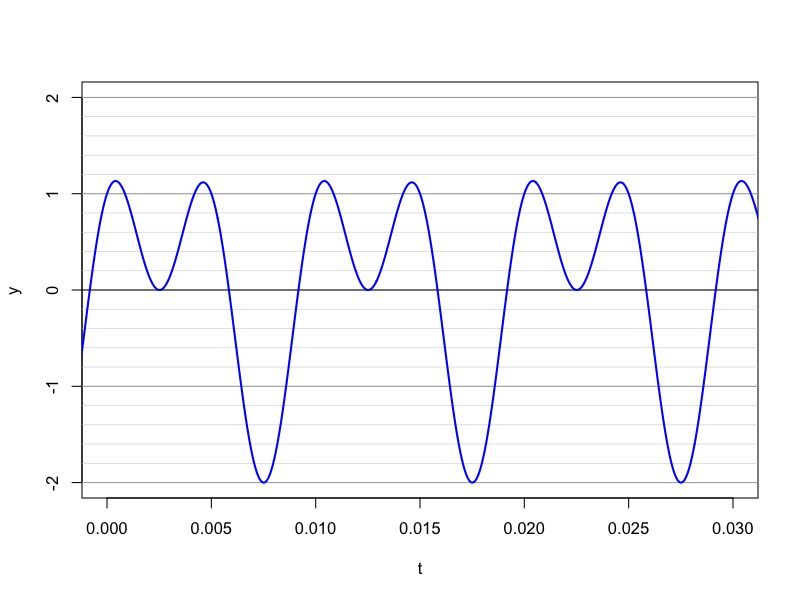

   Notice, you’ll need to selectively zoom in on the horizontal axis.